# Mummichog Report: data_pos_group2_before_blank_subtraction

mummichog version: 2.2.0-20200207, using metabolic model MFN_1.10.4.

## User input data

User supplied 3656 features as reference list.We are using 1216 features (p < 0.050000) as significant list. The feature level data are shown in the Manhattan plots below.

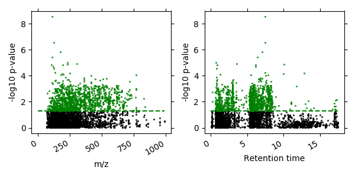

## Top pathways

The reference feature list is mapped to 420 EmpiricalCompounds, significant features to 131 EmpiricalCompounds. In the table below, pathway_size is number of detected EmpiricalCompounds for each pathway; overlap_size is number of significant EmpiricalCompounds. Empirical p-values are estimated by permutation test. Details on EmpiricalCompounds are in 'tables/ListOfEmpiricalCompounds.tsv'.

| Pathways | overlap_size | pathway_size | p-value | overlap_EmpiricalCompounds |
| --- | --- | --- | --- | --- |
| Drug metabolism - cytochrome P450 | 8 | 15 | 0.02697 | E816,E776,E421,E915,E720,E250,E785,E687 |
| Aspartate and asparagine metabolism | 22 | 55 | 0.04495 | E373,E171,E757,E865,E500,E236,E302,E447,E544,E98,E146,E374,E158,E155,E439,E510,E605,E93,E800,E481,E589,E440 |
| Beta-Alanine metabolism | 6 | 11 | 0.04521 | E865,E657,E544,E296,E374,E589 |
| Pentose and Glucuronate Interconversions | 3 | 4 | 0.04722 | E796,E401,E494 |
| Purine metabolism | 13 | 30 | 0.05226 | E425,E763,E753,E811,E10,E374,E416,E128,E589,E274,E691,E866,E494 |

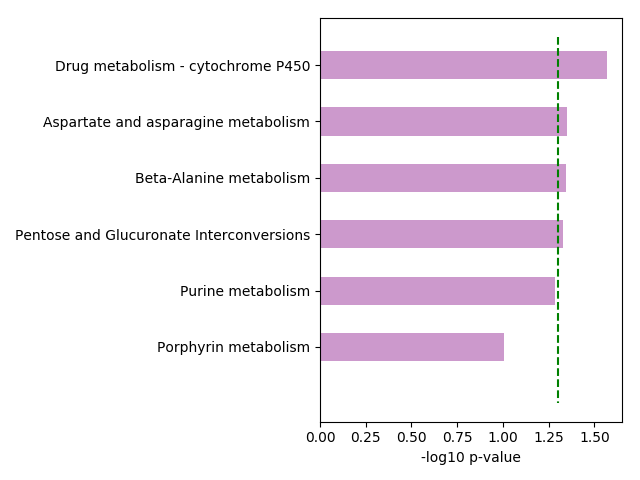

## Top modules

Network modules may capture concerted metabolite activities that are missed by predefined pathways. Use pull-down menus to visualize modules and the activity network, which tries to combine the results of pathway/module analyses. The visualization requires interenet connection.

module_1, p=0.03896, 9 metabolites

L-Adrenaline; (R)-(-)-Adrenaline; (R)-(-)-Epinephrine; (R)-(-)-Epirenamine; (R)-(-)-Adnephrine; 4-[(1R)-1-Hydroxy-2-(methylamino)ethyl]-1,2-benzenediol, L-Normetanephrine, Indole-3-acetaldehyde, N-Methylhistamine, 3,4-Dihydroxyphenylacetaldehyde; Protocatechuatealdehyde, Phenethylamine, 3-Methoxytyramine, Citalopram, N4-Acetylaminobutanal

## EmpiricalCompounds favored by above analyses

An EmpiricalCompound is a computational unit for a tentative metabolite. It can group multiple ions, and be any of the isobaric/isomeric species. This table contains EmpiricalCompounds prioritized by pathway/module analysis.

| EmpiricalCompound | Input m/z | Retention time | ion | mz_diff | Statistic | Significant |
| --- | --- | --- | --- | --- | --- | --- |
| E674 | Best guess: C05127, N-Methylhistamine |  | C05127 |  |  |  |
|  | 126.102882834 | 0.769444736842 | M+H[1+] | 0.0003 | -6.08 | yes |
| E171 | Best guess: CE1938, spermic acid 2 |  | CE1938 |  |  |  |
|  | 233.149946848 | 0.84665 | M+H[1+] | 0.0004 | -4.99 | yes |
| E657 | Best guess: C00099, beta-Alanine |  | C00041, C00213, C00133, C00099 |  |  |  |
|  | 91.0589132343 | 2.30648583333 | M(C13)+H[1+] | 0.0005 | -1.39 | no |
|  | 91.0589483384 | 2.40948030303 | M(C13)+H[1+] | 0.0006 | -2.24 | yes |
|  | 90.0556277793 | 2.31870909091 | M+H[1+] | 0.0007 | -2.39 | yes |
| E447 | Best guess: C03415, N2-Succinyl-L-ornithine |  | C03415 |  |  |  |
|  | 233.113566678 | 2.53194259259 | M+H[1+] | 0.0004 | -1.66 | no |
|  | 233.113587043 | 2.22401315789 | M+H[1+] | 0.0004 | -2.73 | yes |
| E500 | Best guess: CE1938, spermic acid 2 |  | CE1938 |  |  |  |
|  | 255.131582194 | 2.94329047619 | M+Na[1+] | 0.0 | -3.4 | yes |
|  | 233.149851295 | 2.86598981481 | M+H[1+] | 0.0003 | -2.87 | yes |
| E236 | Best guess: C03196, (S)-2-Hydroxyglutarate |  | C02266, C01087, C02630, C03196 |  |  |  |
|  | 171.02676573 | 1.61818529412 | M+Na[1+] | 0.0003 | -4.03 | yes |
| E373 | Best guess: C03740, 5-L-Glutamyl-L-alanine |  | C03740 |  |  |  |
|  | 219.09796348 | 1.19032631579 | M+H[1+] | 0.0004 | -3.2 | yes |
|  | 219.097904389 | 1.04370964912 | M+H[1+] | 0.0004 | -2.32 | yes |
| E589 | Best guess: C00302, DL-Glutamate |  | C00217, C05938, C00025, C00302 |  |  |  |
|  | 148.06072817 | 2.93435882353 | M+H[1+] | 0.0003 | -0.51 | no |
|  | 148.060738731 | 2.9864 | M+H[1+] | 0.0003 | -4.15 | yes |
| E439 | Best guess: C00148, L-Proline |  | C00763, CE4788, C00148 |  |  |  |
|  | 138.053276561 | 0.210896969697 | M+Na[1+] | 0.0007 | -3.87 | yes |
| E296 | Best guess: C00135, L-Histidine |  | C00135 |  |  |  |
|  | 156.077074968 | 17.1357651515 | M+H[1+] | 0.0003 | -2.2 | yes |
| E796 | Best guess: C00191, D-Glucuronate |  | C00618, C06472, C00191 |  |  |  |
|  | 217.031463294 | 2.0662254902 | M+Na[1+] | -0.0005 | -2.99 | yes |
| E623 | Best guess: C04043, 3,4-Dihydroxyphenylacetaldehyde |  | C00642, C04043, C05852, C13636 |  |  |  |
|  | 153.054135511 | 2.20338484848 | M+H[1+] | -0.0004 | -2.87 | yes |

[output cut: 76 more lines]

## More data

Full data tables from pathway analysis, module analysis and activity network are stored in the 'tables/' directory. The tsv files can be imported into a spreadsheet program, e.g. MS Excel. Under the 'figures/network_modules/' directory are files intended for Cytoscape (cytoscape.org) visualization. Please refer to Cytoscape's guides for details. Details of this run are recorded in file mummichog.log.txt.